# Brain Stroke Prediction

# 1 1. Introduction

This paper continues our discussion on [Brain Stroke Prediction](https://www.kaggle.com/datasets/fedesoriano/stroke-prediction-dataset). Stroke is one of the leading causes of death and disability in the USA. Given this context our basic SMART question remains the same: What are the most accurate predictors of the likelihood of having a brain stroke? This results to be a classification problem on the target variable of having a stroke, and we will apply 3 different approaches learned throughout the course to try to solve it.

Included in our discussion is some Exploratory Data Analysis (EDA) from our first assignment, along with some new models, including Logistic Regression, Decision Tree Classifier, and Random Forest Classifier.

# 2 2. EDA

The following are excerpts and graphs from the EDA section of our previous report. We are including them here to remind the reader of our dataset’s attributes, before we dive into the analysis.

```
## 'data.frame':    5110 obs. of  12 variables:
##  $ id               : int  9046 51676 31112 60182 1665 56669 53882 10434 27419 60491 ...
##  $ gender           : chr  "Male" "Female" "Male" "Female" ...
##  $ age              : num  67 61 80 49 79 81 74 69 59 78 ...
##  $ hypertension     : int  0 0 0 0 1 0 1 0 0 0 ...
##  $ heart_disease    : int  1 0 1 0 0 0 1 0 0 0 ...
##  $ ever_married     : chr  "Yes" "Yes" "Yes" "Yes" ...
##  $ work_type        : chr  "Private" "Self-employed" "Private" "Private" ...
##  $ Residence_type   : chr  "Urban" "Rural" "Rural" "Urban" ...
##  $ avg_glucose_level: num  229 202 106 171 174 ...
##  $ bmi              : chr  "36.6" "N/A" "32.5" "34.4" ...
##  $ smoking_status   : chr  "formerly smoked" "never smoked" "never smoked" "smokes" ...
##  $ stroke           : int  1 1 1 1 1 1 1 1 1 1 ...
```

Out of 5110 observations, we can see there are 4860 no stroke observations, while there are 250 stroke observations.

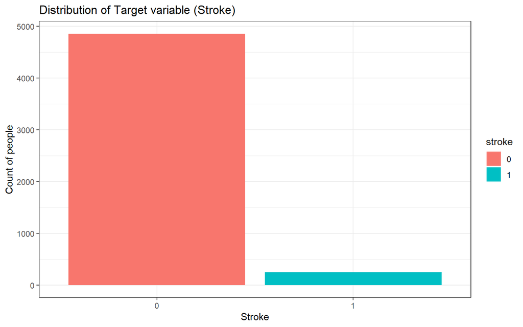

## 2.1 2.1 Important Features Comparisions

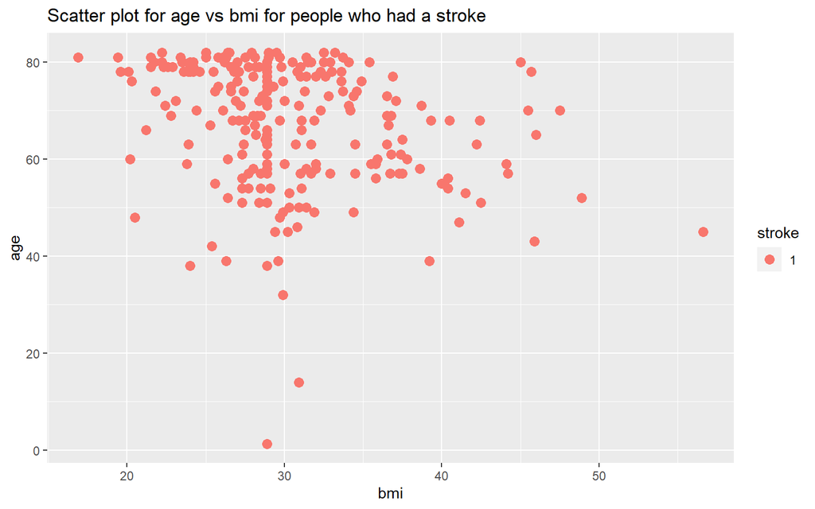

From the scatterplot it is evident that most of the data points fall between the BMI range of 25-35 which is categorized as overweight and obese.

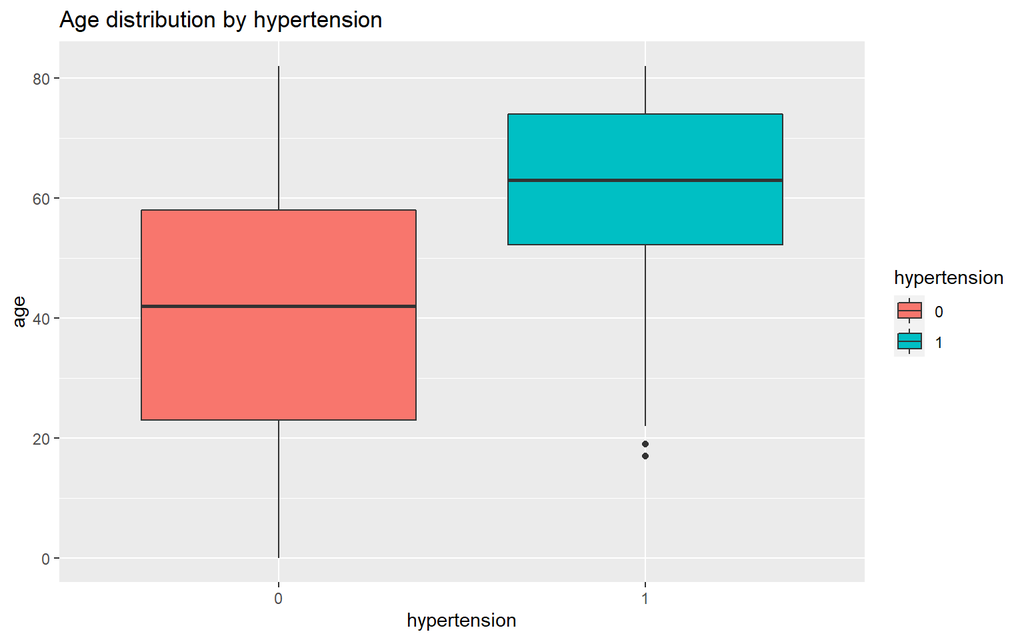

From the boxplot we can see that as age increases the chances of having Hypertension also increases, which can lead to an individual having a stroke.

# 3 Modeling Techniques

## 3.1 Addressing the imbalance issue in the dataset

A dataset is said to be imbalanced when the number of observations per class is not equally distributed among the training dataset. There has been a heavy class imbalance in our dataset as mentioned above.

To reduce the imbalance dataset two sampling methods were performed. They are:

**ROSE (Random OverSampler Examples)**

**SMOTE (Synthetic Minority Oversampling Technique)**

## 3.2 SMOTE

SMOTE technique involves creating a new dataset by oversampling observations from the minority class, which produces a dataset that has more balanced classes.

## 3.3 Feature Selection

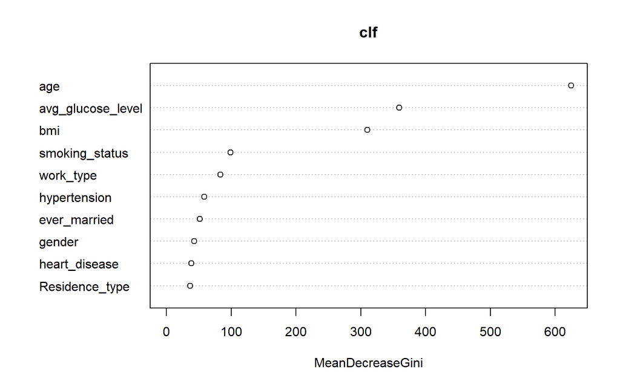

Random forests consist of 4 –12 hundred decision trees, each of them built over a random extraction of the observations from the dataset and a random extraction of the features. Not every tree sees all the features or all the observations, and this guarantees that the trees are de-correlated and therefore less prone to over-fitting. Each tree is also a sequence of yes-no questions based on a single or combination of features. At each node (this is at each question), the three divides the dataset into 2 buckets, each of them hosting observations that are more similar among themselves and different from the ones in the other bucket. Therefore, the importance of each feature is derived from how “pure” each of the buckets is.

### 3.3.1 Logistic Regression - SMOTE

Logit is a type of generalized inear model (GLiM) that usees statistical analysis to predict an event based on known factors when using a dichotomous dependent variable. In the logit model the log odds of the outcome is modeled as a linear combination of the predictor variables.

```
##
##     FALSE TRUE
##   0  1085  374
##   1    10   58
```

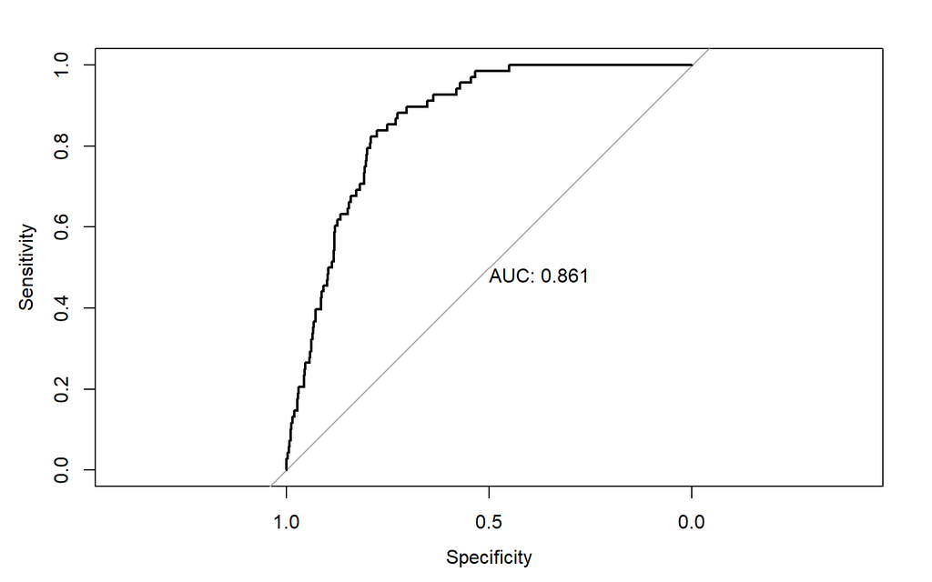

```
##
## Call:
## roc.formula(formula = test$stroke ~ test_prob, plot = TRUE, print.auc = TRUE)
##
## Data: test_prob in 1459 controls (test$stroke 0) < 68 cases (test$stroke 1).
## Area under the curve: 0.861
```

```
## [1] "Accuracy for test 0.74852652259332"
```

```
## [1] "recall_score for test 0.852941176470588"
```

### 3.3.2 Logistic Regression with feature selected variables - SMOTE

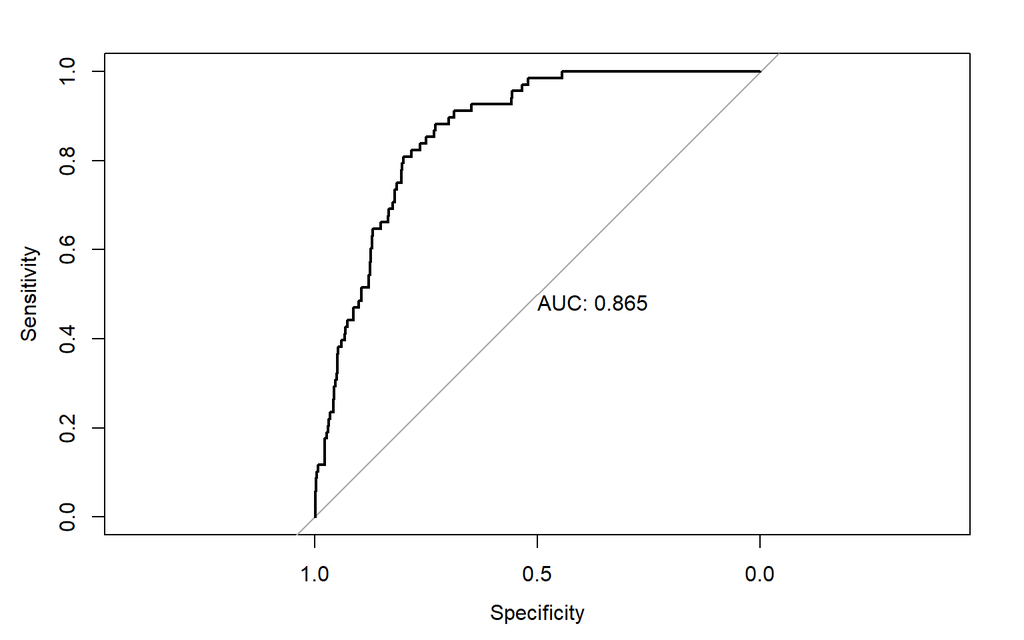

```
##
## Call:
## roc.formula(formula = test_fe$stroke ~ test_prob, plot = TRUE,     print.auc = TRUE)
##
## Data: test_prob in 1459 controls (test_fe$stroke 0) < 68 cases (test_fe$stroke 1).
## Area under the curve: 0.865
```

```
## [1] "Accuracy for test 0.740013097576948"
```

```
## [1] "recall_score for test 0.852941176470588"
```

### 3.3.3 Decision Tree - SMOTE

Decision Trees are versatile machine learning algorithm that carry out both classification and regression tasks. They are extremely powerful algorithms that can successfully fit complex datasets.

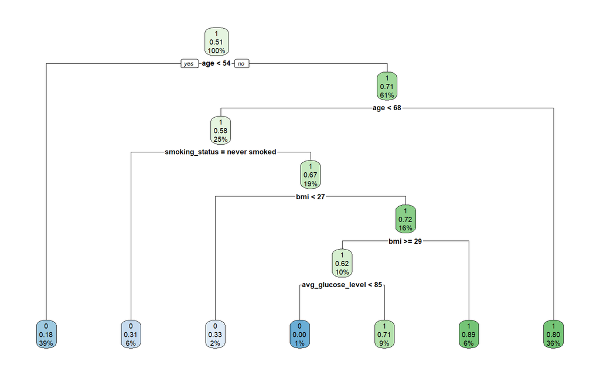

```
## [1] "Accuracy for test 0.79109364767518"
```

```
## [1] "recall_score for test 0.794117647058823"
```

### 3.3.4 Decision Tree with Feature Selection - SMOTE

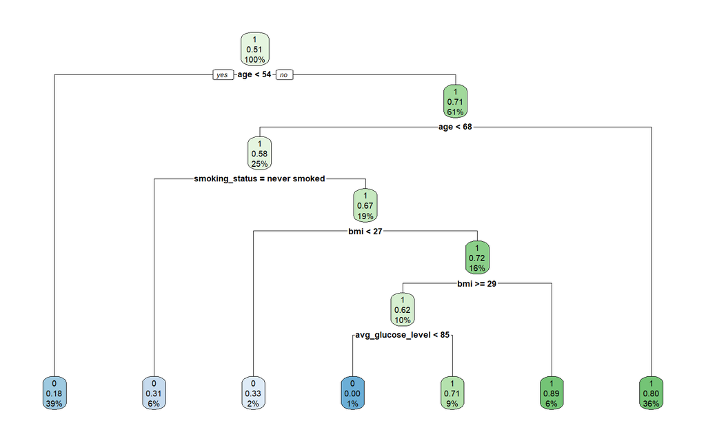

```
## [1] "Accuracy for test 0.79109364767518"
```

```
## [1] "recall_score for test 0.794117647058823"
```

### 3.3.5 Tuned Decision Tree - SMOTE

Decision tree in R has various parameters that control aspects of the fit. In rpart decision tree library, we can control the parameters using the rpart.control() function. In the following code we have introduced the parameters that need to be tuned.

```
## [1] "Accuracy for test 0.769482645710544"
```

```
## [1] "recall_score for test 0.808823529411765"
```

### 3.3.6 Tuned Decision Tree with Feature Selection - SMOTE

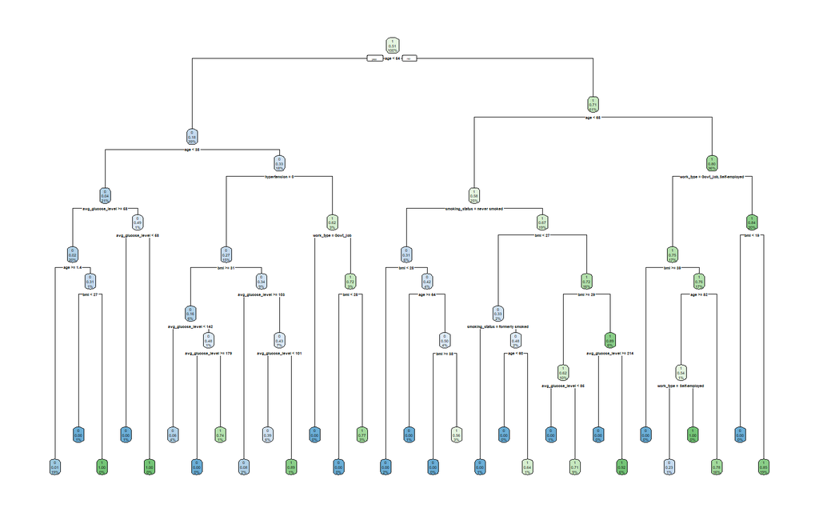

```
## [1] "Accuracy for test 0.740667976424361"
```

```
## [1] "recall_score for test 0.823529411764706"
```

### 3.3.7 Random Forest

Random Forest is a collection of decision trees. To obtain more precise predictions, it constructs and merges several decision trees. The classification algorithm is non-linear. When utilized independently, each decision tree model is used.

```
## [1] "Accuracy for test 0.916175507531107"
```

```
## [1] "recall_score for test 0.25"
```

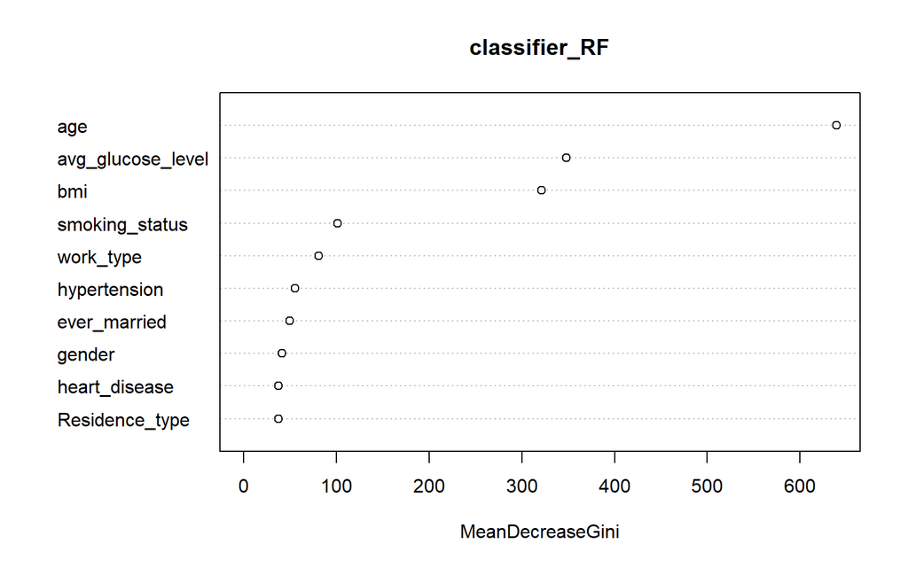

### 3.3.8 Random Forest with Feature Selected Variables

```
## [1] "Accuracy for test 0.907007203667322"
```

```
## [1] "recall_score for test 0.323529411764706"
```

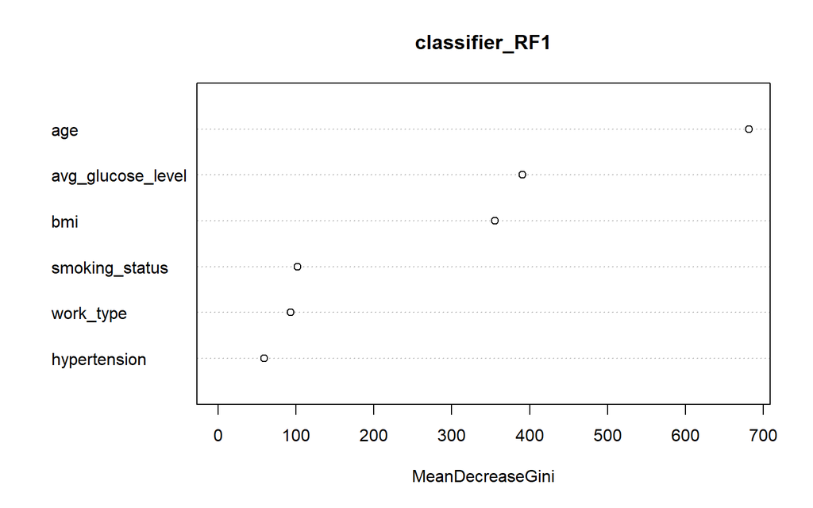

## 3.4 ROSE

ROSE is Random Over Sampling Examples. It expands the feature space of minority and majority class examples to provide a sample of synthetic data. Operationally, a conditional kernel density estimate of the two classes is used to generate the new samples.

### 3.4.1 Logistic Regression - ROSE

```
## [1] "Accuracy for test 0.743931088488645"
```

```
## [1] "recall_score for test 0.895833333333333"
```

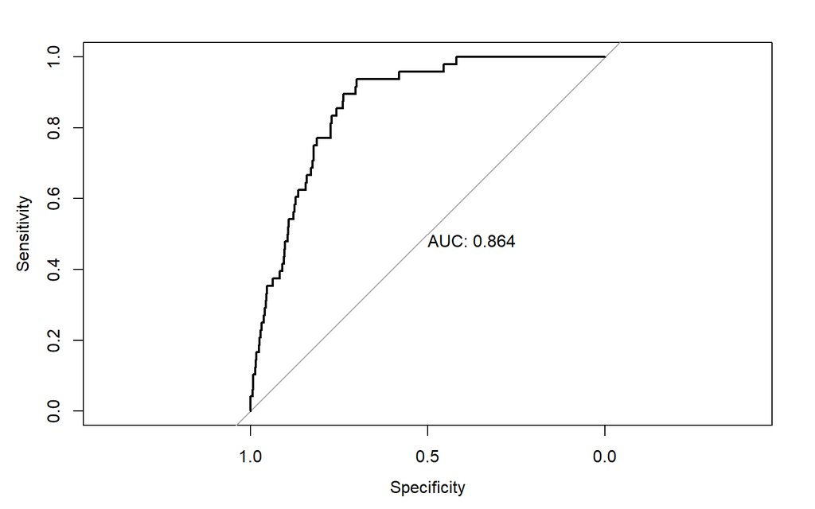

```
##
## Call:
## roc.formula(formula = test1$stroke ~ test_prob, plot = TRUE,     print.auc = TRUE)
##
## Data: test_prob in 1229 controls (test1$stroke 0) < 48 cases (test1$stroke 1).
## Area under the curve: 0.864
```

### 3.4.2 Logistic Regression with Feature Selection - ROSE

```
##
##     FALSE TRUE
##   0   907  322
##   1     6   42
```

```
## [1] "Accuracy for test 0.743148003132341"
```

```
## [1] "recall_score for test 0.875"
```

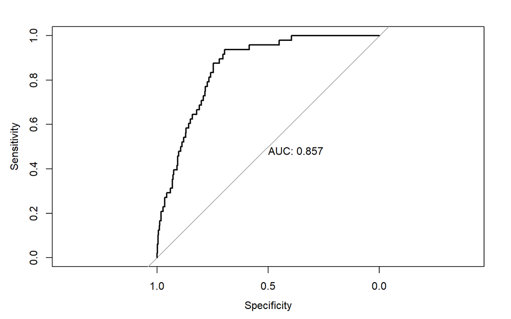

### 3.4.3 DECISION TREE - ROSE

```
## [1] "Accuracy for test 0.734534064212999"
```

```
## [1] "recall_score for test 0.791666666666667"
```

### 3.4.4 DECISION TREE with Feature Selection - ROSE

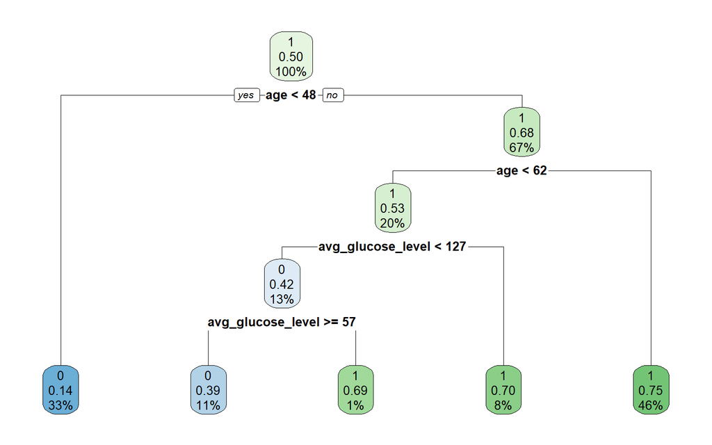

```
## [1] "Accuracy for test 0.734534064212999"
```

```
## [1] "recall_score for test 0.791666666666667"
```

### 3.4.5 Tuned Decision Tree - ROSE

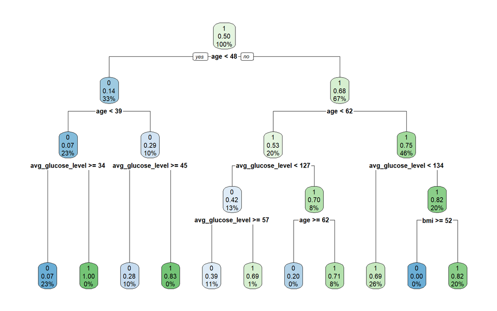

```
## [1] "Accuracy for test 0.736100234925607"
```

```
## [1] "recall_score for test 0.791666666666667"
```

### 3.4.7 Random Forest

```
## [1] "Accuracy for test 0.782302270947533"
```

```
## [1] "recall_score for test 0.520833333333333"
```

### 3.4.8 Random Forest with feature selection

```
## [1] "Accuracy for test 0.750195771339076"
```

```
## [1] "recall_score for test 0.645833333333333"
```